# Apuntes Data Cleaning II

Pilar Amat Rodrigo

7/12/2017

## **Exercise 1_Sales**

Data_Sales: https://assets.datacamp.com/production/course_1294/datasets/sales.csv

### **Importing**

```r
#Import sales.csv to the variable sales using the read.csv() function. Set the stringsAsFactors argument to FALSE so that character strings are preserved.

sales<- read.csv("sales.csv",stringsAsFactors=FALSE)
```

### **Examining the data**

```r
# View dimensions of sales
dim(sales)
```

```
## [1] 5000   46
```

```r
# Inspect first 6 rows of sales
head(sales, n=6)
```

```
##   X             event_id       primary_act_id     secondary_act_id
## 1 1 abcaf1adb99a935fc661 43f0436b905bfa7c2eec b85143bf51323b72e53c
## 2 2 6c56d7f08c95f2aa453c 1a3e9aecd0617706a794 f53529c5679ea6ca5a48
## 3 3 c7ab4524a121f9d687d2 4b677c3f5bec71eec8d1 b85143bf51323b72e53c
## 4 4 394cb493f893be9b9ed1 b1ccea01ad6ef8522796 b85143bf51323b72e53c
## 5 5 55b5f67e618557929f48 91c03a34b562436efa3c b85143bf51323b72e53c
## 6 6 4f10fd8b9f550352bd56 ac4b847b3fde66f2117e 63814f3d63317f1b56c4
##    purch_party_lkup_id
## 1 7dfa56dd7d5956b17587
## 2 4f9e6fc637eaf7b736c2
## 3 6c2545703bd527a7144d
## 4 527d6b1eaffc69ddd882
## 5 8bd62c394a35213bdf52
## 6 3b3a628f83135acd0676
##                                                       event_name
```

[output cut: 97 more lines]

```r
# View column names of sales
names(sales)
```

```
##  [1] "X"                      "event_id"
##  [3] "primary_act_id"         "secondary_act_id"
##  [5] "purch_party_lkup_id"    "event_name"
##  [7] "primary_act_name"       "secondary_act_name"
##  [9] "major_cat_name"         "minor_cat_name"
## [11] "la_event_type_cat"      "event_disp_name"
## [13] "ticket_text"            "tickets_purchased_qty"
## [15] "trans_face_val_amt"     "delivery_type_cd"
## [17] "event_date_time"        "event_dt"
## [19] "presale_dt"             "onsale_dt"
## [21] "sales_ord_create_dttm"  "sales_ord_tran_dt"
## [23] "print_dt"               "timezn_nm"
## [25] "venue_city"             "venue_state"
## [27] "venue_postal_cd_sgmt_1" "sales_platform_cd"
## [29] "print_flg"              "la_valid_tkt_event_flg"
## [31] "fin_mkt_nm"             "web_session_cookie_val"
## [33] "gndr_cd"                "age_yr"
## [35] "income_amt"             "edu_val"
## [37] "edu_1st_indv_val"       "edu_2nd_indv_val"
## [39] "adults_in_hh_num"       "married_ind"
## [41] "child_present_ind"      "home_owner_ind"
## [43] "occpn_val"              "occpn_1st_val"
## [45] "occpn_2nd_val"          "dist_to_ven"
```

```r
#take a look with glimpse it's part of the dplyr package
library(dplyr)
glimpse(sales)
```

```
## Observations: 5,000
## Variables: 46
## $ X                      <int> 1, 2, 3, 4, 5, 6, 7, 8, 9, 10, 11, 12, ...
## $ event_id               <chr> "abcaf1adb99a935fc661", "6c56d7f08c95f2...
## $ primary_act_id         <chr> "43f0436b905bfa7c2eec", "1a3e9aecd06177...
## $ secondary_act_id       <chr> "b85143bf51323b72e53c", "f53529c5679ea6...
## $ purch_party_lkup_id    <chr> "7dfa56dd7d5956b17587", "4f9e6fc637eaf7...
## $ event_name             <chr> "Xfinity Center Mansfield Premier Parki...
## $ primary_act_name       <chr> "XFINITY Center Mansfield Premier Parki...
## $ secondary_act_name     <chr> "NULL", "Dave Matthews Band", "NULL", "...
## $ major_cat_name         <chr> "MISC", "MISC", "MISC", "MISC", "MISC",...
## $ minor_cat_name         <chr> "PARKING", "CAMPING", "PARKING", "PARKI...
## $ la_event_type_cat      <chr> "PARKING", "INVALID", "PARKING", "PARKI...
## $ event_disp_name        <chr> "Xfinity Center Mansfield Premier Parki...
## $ ticket_text            <chr> "   THIS TICKET IS VALID        FOR PAR...
```

[output cut: 33 more lines]

**Note:** Notice the first column, X, which appears to just be counting.

Next will be removing first column

```r
#Take a subset of sales to omit the first column. Assign the result to sales2

sales2<- sales[,-1]
head(sales2,n=3)
```

```
##               event_id       primary_act_id     secondary_act_id
## 1 abcaf1adb99a935fc661 43f0436b905bfa7c2eec b85143bf51323b72e53c
## 2 6c56d7f08c95f2aa453c 1a3e9aecd0617706a794 f53529c5679ea6ca5a48
## 3 c7ab4524a121f9d687d2 4b677c3f5bec71eec8d1 b85143bf51323b72e53c
##    purch_party_lkup_id
## 1 7dfa56dd7d5956b17587
## 2 4f9e6fc637eaf7b736c2
## 3 6c2545703bd527a7144d
##                                                       event_name
## 1 Xfinity Center Mansfield Premier Parking: Florida Georgia Line
## 2                  Gorge Camping - dave matthews band - sept 3-7
## 3                    Dodge Theatre Adams Street Parking - benise
##                           primary_act_name secondary_act_name
## 1 XFINITY Center Mansfield Premier Parking               NULL
## 2                            Gorge Camping Dave Matthews Band
```

[output cut: 45 more lines]

Many of the columns have information that’s of no use to us. For example, the first four columns contain internal codes representing particular events. The last fifteen columns also aren’t worth keeping; there are too many missing values to make them worthwhile.

An easy way to get rid of unnecessary columns is to create a vector containing the column indices you want to keep, then subset the data based on that vector using single bracket subsetting.

```r
# Define a vector of column indices: keep

keep<-(5:(ncol(sales2)-15))

# Subset sales2 using keep: sales3
sales3<- sales2[keep]
```

We have a sales3 with 26 variables.

### **Separating columns**

Some of the columns in your data frame include multiple pieces of information that should be in separate columns. In this exercise, you will separate such a column into two: one for date and one for time. You will use the separate() function from the tidyr package (already installed for you).

Take a look at the event_date_time column by typing head(sales3$event_date_time) in the console. You’ll notice that the date and time are separated by a space. Therefore, you’ll use sep = " " as an argument to separate().

```r
# Load tidyr
library(tidyr)

# Split event_date_time in "event_dt", "event_time": sales4
sales4 <- separate(sales3, event_date_time,
                   c("event_dt","event_time"), sep = " ")

# Split sales_ord_create_dttm in "ord_create_dt", "ord_create_time": sales5
sales5 <- separate(sales4, sales_ord_create_dttm,c("ord_create_dt", "ord_create_time"),sep=" ")
```

```
## Warning: Expected 2 pieces. Missing pieces filled with `NA` in 4 rows
## [2516, 3863, 4082, 4183].
```

¡¡Warning message!!

### **Dealing with warnings**

Looks like that second call to separate() threw a warning. Not to worry; warnings aren’t as bad as error messages. It’s not saying that the command didn’t execute; it’s just a heads-up that something unusual happened.

The warning says Too few values at 4 locations. You may be able to guess already what the issue is, but it’s still good to take a look.

The locations (i.e. rows) given in the warning are 2516, 3863, 4082, and 4183. Have a look at the contents of the sales_ord_create_dttm column in those rows.

```r
# lets look at the warnings, we see 4 NA in  $ord_create_time
# Define an issues vector
issues<-c(2516,3863,4082,4183)

# Print values of sales_ord_create_dttm at these indices
sales3$sales_ord_create_dttm[issues]
```

```
## [1] "NULL" "NULL" "NULL" "NULL"
```

```r
# Print a well-behaved value of sales_ord_create_dttm
sales3$sales_ord_create_dttm[2517]
```

```
## [1] "2013-08-04 23:07:19"
```

The warning was just because of four missing values. You’ll ignore them for now, but if your analysis depended on complete date/time information, you would probably need to delete those rows.

### **Identifying dates**

Some of the columns in your dataset contain dates of different events. Right now, they are stored as character strings. That’s fine if all you want to do is look up the date associated with an event, but if you want to do any comparisons or math with the dates, it’s MUCH easier to store them as Date objects.

Luckily, all of the date columns in this dataset have the substring “dt” in their name, so you can use the **str_detect()** function of the **stringr package** to find the date columns. Then you can coerce them to Date objects using a function from the **lubridate package**.

You’ll use **lapply()** to apply the appropriate lubridate function to all of the columns that contain dates. Recall the following syntax for lapply() applied to some data frame columns of interest:

```
lapply(my_data_frame[, cols], function_name)
```

Also recall that function names in lubridate combine the letters y, m, d, h, m, and s depending on the format of the date/time string being read in.

```r
# Load stringr
library(stringr)

# Find columns of sales5 containing "dt": date_cols
date_cols<-str_detect(names(sales5), pattern="dt")

# Load lubridate
library(lubridate)
# Coerce date columns into Date objects
sales5[, date_cols] <- lapply(sales5[, date_cols], ymd)
```

```
## Warning: 2892 failed to parse.
```

```
## Warning: 101 failed to parse.
```

```
## Warning: 4 failed to parse.
```

```
## Warning: 424 failed to parse.
```

**More warnings!** As you saw, some of the calls to ymd() caused a failure to parse warning. That’s probably because of more missing data, but again, it’s good to check to be sure.

The first two lines of code (provided for you here) create a list of logical vectors called missing. Each vector in the list indicates the presence (or absence) of missing values in the corresponding column of sales5. See if the number of missing values in each column is the same as the number of rows that failed to parse in the previous exercise.

```r
# Find date columns (don't change)
date_cols <- str_detect(names(sales5), "dt")

# Create logical vectors indicating missing values (don't change)
missing<- lapply(sales5[,date_cols],is.na)

# Create a numerical vector that counts missing values: num_missing
num_missing<- sapply(missing,sum)

# Print num_missing
print(num_missing)
```

```
##          event_dt        presale_dt         onsale_dt     ord_create_dt
##                 0              2892               101                 4
## sales_ord_tran_dt          print_dt
##                 0               424
```

### **Combining columns**

Sure enough, the number of NAs in each column match the numbers from the warning messages, so missing data is the culprit. How to proceed depends on your desired analysis. If you really need complete sets of date/time information, you might delete the rows or columns containing NAs.

As your last step, you’ll use the tidyr function **unite()** to combine the venue_city and venue_state columns into one column with the two values separated by a comma and a space. For example, “PORTLAND” “MAINE” should become “PORTLAND, MAINE”.

```r
# Combine the venue_city and venue_state columns
sales6<- unite(sales5, "venue_city_state", "venue_city", "venue_state", sep=", ")


# View the head of sales6
glimpse(sales6$venue_city_state)
```

```
##  chr [1:5000] "MANSFIELD, MASSACHUSETTS" "QUINCY, WASHINGTON" ...
```

## **Exercise 2_MBTransportation**

Data_Sales: https://www.datacamp.com/courses/importing-cleaning-data-in-r-case-studies

### **Importing**

The dataset is stored as an Excel spreadsheet called mbta.xlsx in your working directory. You’ll use the read_excel() function from Hadley Wickham’s readxl package to import it.

The first time you import a dataset, you might not know how many rows need to be skipped. In this case, the first row is a title, so you’ll need to skip the first row.

```r
library(readxl)

# Import mbta.xlsx and skip first row: mbta
mbta<-read_excel("mbta.xlsx", skip = 1)
```

### **Examining the Data**

```r
# View the structure of mbta
str(mbta)
```

```
## Classes 'tbl_df', 'tbl' and 'data.frame':    11 obs. of  60 variables:
##  $ X__1   : num  1 2 3 4 5 6 7 8 9 10 ...
##  $ mode   : chr  "All Modes by Qtr" "Boat" "Bus" "Commuter Rail" ...
##  $ 2007-01: chr  "NA" "4" "335.819" "142.2" ...
##  $ 2007-02: chr  "NA" "3.6" "338.675" "138.5" ...
##  $ 2007-03: num  1188 40 340 138 459 ...
##  $ 2007-04: chr  "NA" "4.3" "352.162" "139.5" ...
##  $ 2007-05: chr  "NA" "4.9" "354.367" "139" ...
##  $ 2007-06: num  1246 5.8 350.5 143 477 ...
##  $ 2007-07: chr  "NA" "6.521" "357.519" "142.391" ...
##  $ 2007-08: chr  "NA" "6.572" "355.479" "142.364" ...
##  $ 2007-09: num  1256.57 5.47 372.6 143.05 499.57 ...
##  $ 2007-10: chr  "NA" "5.145" "368.847" "146.542" ...
##  $ 2007-11: chr  "NA" "3.763" "330.826" "145.089" ...
##  $ 2007-12: num  1216.89 2.98 312.92 141.59 448.27 ...
```

[output cut: 46 more lines]

```r
# View the first 6 rows of mbta
head(mbta, n=6)
```

```
## # A tibble: 6 x 60
##    X__1 mode   `2007-01` `2007-02` `2007-03` `2007-04` `2007-05` `2007-06`
##   <dbl> <chr>  <chr>     <chr>         <dbl> <chr>     <chr>         <dbl>
## 1     1 All M… NA        NA            1188. NA        NA           1246.
## 2     2 Boat   4         3.6             40  4.3       4.9             5.8
## 3     3 Bus    335.819   338.675        340. 352.162   354.367       351.
## 4     4 Commu… 142.2     138.5          138. 139.5     139           143
## 5     5 Heavy… 435.294   448.271        459. 472.201   474.579       477.
## 6     6 Light… 227.231   240.262        241. 255.557   248.262       246.
## # ... with 52 more variables: `2007-07` <chr>, `2007-08` <chr>,
## #   `2007-09` <dbl>, `2007-10` <chr>, `2007-11` <chr>, `2007-12` <dbl>,
## #   `2008-01` <chr>, `2008-02` <chr>, `2008-03` <dbl>, `2008-04` <chr>,
## #   `2008-05` <chr>, `2008-06` <dbl>, `2008-07` <chr>, `2008-08` <chr>,
## #   `2008-09` <dbl>, `2008-10` <chr>, `2008-11` <chr>, `2008-12` <dbl>,
## #   `2009-01` <chr>, `2009-02` <chr>, `2009-03` <dbl>, `2009-04` <chr>,
## #   `2009-05` <chr>, `2009-06` <dbl>, `2009-07` <chr>, `2009-08` <chr>,
## #   `2009-09` <dbl>, `2009-10` <chr>, `2009-11` <chr>, `2009-12` <dbl>,
## #   `2010-01` <chr>, `2010-02` <chr>, `2010-03` <dbl>, `2010-04` <chr>,
## #   `2010-05` <chr>, `2010-06` <dbl>, `2010-07` <chr>, `2010-08` <chr>,
## #   `2010-09` <dbl>, `2010-10` <chr>, `2010-11` <chr>, `2010-12` <dbl>,
## #   `2011-01` <chr>, `2011-02` <chr>, `2011-03` <dbl>, `2011-04` <chr>,
## #   `2011-05` <chr>, `2011-06` <dbl>, `2011-07` <chr>, `2011-08` <chr>,
## #   `2011-09` <dbl>, `2011-10` <chr>
```

```r
# View a summary of mbta
summary(mbta)
```

```
##       X__1          mode             2007-01            2007-02
##  Min.   : 1.0   Length:11          Length:11          Length:11
##  1st Qu.: 3.5   Class :character   Class :character   Class :character
##  Median : 6.0   Mode  :character   Mode  :character   Mode  :character
##  Mean   : 6.0
##  3rd Qu.: 8.5
##  Max.   :11.0
##     2007-03           2007-04            2007-05
##  Min.   :   0.114   Length:11          Length:11
##  1st Qu.:   9.278   Class :character   Class :character
##  Median : 137.700   Mode  :character   Mode  :character
##  Mean   : 330.293
##  3rd Qu.: 399.225
##  Max.   :1204.725
##     2007-06           2007-07            2007-08
##  Min.   :   0.096   Length:11          Length:11
##  1st Qu.:   5.700   Class :character   Class :character
##  Median : 143.000   Mode  :character   Mode  :character
##  Mean   : 339.846
##  3rd Qu.: 413.788
##  Max.   :1246.129
##     2007-09           2007-10            2007-11
##  Min.   :  -0.007   Length:11          Length:11
##  1st Qu.:   5.539   Class :character   Class :character
##  Median : 143.051   Mode  :character   Mode  :character
##  Mean   : 352.554
##  3rd Qu.: 436.082
##  Max.   :1310.764
##     2007-12           2008-01            2008-02
##  Min.   :  -0.060   Length:11          Length:11
##  1st Qu.:   4.385   Class :character   Class :character
##  Median : 141.585   Mode  :character   Mode  :character
##  Mean   : 321.588
##  3rd Qu.: 380.594
##  Max.   :1216.890
##     2008-03           2008-04            2008-05
##  Min.   :   0.058   Length:11          Length:11
##  1st Qu.:   5.170   Class :character   Class :character
##  Median : 137.453   Mode  :character   Mode  :character
##  Mean   : 345.604
```

[output cut: 85 more lines]

```
##  Max.   :1286.66
##     2011-06           2011-07            2011-08
##  Min.   :   0.054   Length:11          Length:11
##  1st Qu.:   6.926   Class :character   Class :character
##  Median : 135.581   Mode  :character   Mode  :character
##  Mean   : 353.331
##  3rd Qu.: 452.923
##  Max.   :1302.414
##     2011-09           2011-10
##  Min.   :   0.043   Length:11
##  1st Qu.:   6.660   Class :character
##  Median : 136.901   Mode  :character
##  Mean   : 362.555
##  3rd Qu.: 469.204
##  Max.   :1348.754
```

### **Removing unnecessary rows and columns**

```r
# Remove the first, seventh, and eleventh rows of mbta (All Modes By Qtr, Pct Chg / Yr, and TOTAL). Name the resulting data frame mbta2.
mbta2<- mbta[-(c(1,7,11)),]

# Remove the first column of mbta2. Name the resulting data frame mbta3

mbta3<-mbta2[,-1]
head(mbta3)
```

```
## # A tibble: 6 x 59
##   mode         `2007-01` `2007-02` `2007-03` `2007-04` `2007-05` `2007-06`
##   <chr>        <chr>     <chr>         <dbl> <chr>     <chr>         <dbl>
## 1 Boat         4         3.6           40    4.3       4.9            5.8
## 2 Bus          335.819   338.675      340.   352.162   354.367      351.
## 3 Commuter Ra… 142.2     138.5        138.   139.5     139          143
## 4 Heavy Rail   435.294   448.271      459.   472.201   474.579      477.
## 5 Light Rail   227.231   240.262      241.   255.557   248.262      246.
## 6 Private Bus  4.772     4.417          4.57 4.542     4.768          4.72
## # ... with 52 more variables: `2007-07` <chr>, `2007-08` <chr>,
## #   `2007-09` <dbl>, `2007-10` <chr>, `2007-11` <chr>, `2007-12` <dbl>,
## #   `2008-01` <chr>, `2008-02` <chr>, `2008-03` <dbl>, `2008-04` <chr>,
## #   `2008-05` <chr>, `2008-06` <dbl>, `2008-07` <chr>, `2008-08` <chr>,
## #   `2008-09` <dbl>, `2008-10` <chr>, `2008-11` <chr>, `2008-12` <dbl>,
## #   `2009-01` <chr>, `2009-02` <chr>, `2009-03` <dbl>, `2009-04` <chr>,
## #   `2009-05` <chr>, `2009-06` <dbl>, `2009-07` <chr>, `2009-08` <chr>,
## #   `2009-09` <dbl>, `2009-10` <chr>, `2009-11` <chr>, `2009-12` <dbl>,
## #   `2010-01` <chr>, `2010-02` <chr>, `2010-03` <dbl>, `2010-04` <chr>,
## #   `2010-05` <chr>, `2010-06` <dbl>, `2010-07` <chr>, `2010-08` <chr>,
## #   `2010-09` <dbl>, `2010-10` <chr>, `2010-11` <chr>, `2010-12` <dbl>,
## #   `2011-01` <chr>, `2011-02` <chr>, `2011-03` <dbl>, `2011-04` <chr>,
## #   `2011-05` <chr>, `2011-06` <dbl>, `2011-07` <chr>, `2011-08` <chr>,
## #   `2011-09` <dbl>, `2011-10` <chr>
```

### **Observations are stored in columns**

As is customary, you want to represent variables in columns rather than rows. The first step is to use the **gather()** function from the **tidyr package**, which will gather columns into key-value pairs.

```r
library(tidyr)

# Gather columns of mbta3: mbta4
mbta4<- gather(data = mbta3, key = "month",value = "thou_riders", -mode)

# View the head of mbta4
head(mbta4)
```

```
## # A tibble: 6 x 3
##   mode          month   thou_riders
##   <chr>         <chr>   <chr>
## 1 Boat          2007-01 4
## 2 Bus           2007-01 335.819
## 3 Commuter Rail 2007-01 142.2
## 4 Heavy Rail    2007-01 435.294
## 5 Light Rail    2007-01 227.231
## 6 Private Bus   2007-01 4.772
```

### **Type conversions**

But first, take this opportunity to change the average weekday ridership column, thou_riders, into numeric values rather than character strings. That way, you’ll be able to do things like compare values and do math.

```r
# Coerce thou_riders to numeric

mbta4$thou_riders<-as.numeric(mbta4$thou_riders)

head(mbta4,n=5)
```

```
## # A tibble: 5 x 3
##   mode          month   thou_riders
##   <chr>         <chr>         <dbl>
## 1 Boat          2007-01          4
## 2 Bus           2007-01        336.
## 3 Commuter Rail 2007-01        142.
## 4 Heavy Rail    2007-01        435.
## 5 Light Rail    2007-01        227.
```

### **Variables are stored in both rows and columns**

Now, you can finish the job you started earlier: getting variables into columns. Right now, variables are stored as “keys” in the mode column. You’ll use the tidyr function spread() to make them into columns containing average weekday ridership for the given month and mode of transport.

```r
# Spread the contents of mbta4: mbta5
mbta5<- spread(mbta4,mode,thou_riders)

# View the head of mbta5
head(mbta5)
```

```
## # A tibble: 6 x 9
##   month    Boat   Bus `Commuter Rail` `Heavy Rail` `Light Rail`
##   <chr>   <dbl> <dbl>           <dbl>        <dbl>        <dbl>
## 1 2007-01   4    336.            142.         435.         227.
## 2 2007-02   3.6  339.            138.         448.         240.
## 3 2007-03  40    340.            138.         459.         241.
## 4 2007-04   4.3  352.            140.         472.         256.
## 5 2007-05   4.9  354.            139          475.         248.
## 6 2007-06   5.8  351.            143          477.         246.
## # ... with 3 more variables: `Private Bus` <dbl>, RIDE <dbl>, `Trackless
## #   Trolley` <dbl>
```

### **Separating columns**

In this exercise, you’ll separate the month column into distinct month and year columns to make life easier.

```r
# Split month column into month and year: mbta6
mbta6<- separate(mbta5, month, c("year","month"), sep="-")

# View the head of mbta6
head(mbta6,n=3)
```

```
## # A tibble: 3 x 10
##   year  month  Boat   Bus `Commuter Rail` `Heavy Rail` `Light Rail`
##   <chr> <chr> <dbl> <dbl>           <dbl>        <dbl>        <dbl>
## 1 2007  01      4    336.            142.         435.         227.
## 2 2007  02      3.6  339.            138.         448.         240.
## 3 2007  03     40    340.            138.         459.         241.
## # ... with 3 more variables: `Private Bus` <dbl>, RIDE <dbl>, `Trackless
## #   Trolley` <dbl>
```

### **Outliers**

Let’s take a look of summary to see if there is any possible outlier. It may be sthng weird in Boat.

```r
# View a summary of mbta6
summary(mbta6)
```

```
##      year              month                Boat             Bus
##  Length:58          Length:58          Min.   : 2.985   Min.   :312.9
##  Class :character   Class :character   1st Qu.: 3.494   1st Qu.:345.6
##  Mode  :character   Mode  :character   Median : 4.293   Median :359.9
##                                        Mean   : 5.068   Mean   :358.6
##                                        3rd Qu.: 5.356   3rd Qu.:372.2
##                                        Max.   :40.000   Max.   :398.5
##  Commuter Rail     Heavy Rail      Light Rail     Private Bus
##  Min.   :121.4   Min.   :435.3   Min.   :194.4   Min.   :2.213
##  1st Qu.:131.4   1st Qu.:471.1   1st Qu.:220.6   1st Qu.:2.641
##  Median :138.8   Median :487.3   Median :231.9   Median :2.820
##  Mean   :137.4   Mean   :489.3   Mean   :233.0   Mean   :3.352
##  3rd Qu.:142.4   3rd Qu.:511.3   3rd Qu.:244.5   3rd Qu.:4.167
##  Max.   :153.0   Max.   :554.9   Max.   :271.1   Max.   :4.878
##       RIDE       Trackless Trolley
##  Min.   :4.900   Min.   : 5.777
##  1st Qu.:5.965   1st Qu.:11.679
##  Median :6.615   Median :12.598
##  Mean   :6.604   Mean   :12.125
##  3rd Qu.:7.149   3rd Qu.:13.320
##  Max.   :8.598   Max.   :15.109
```

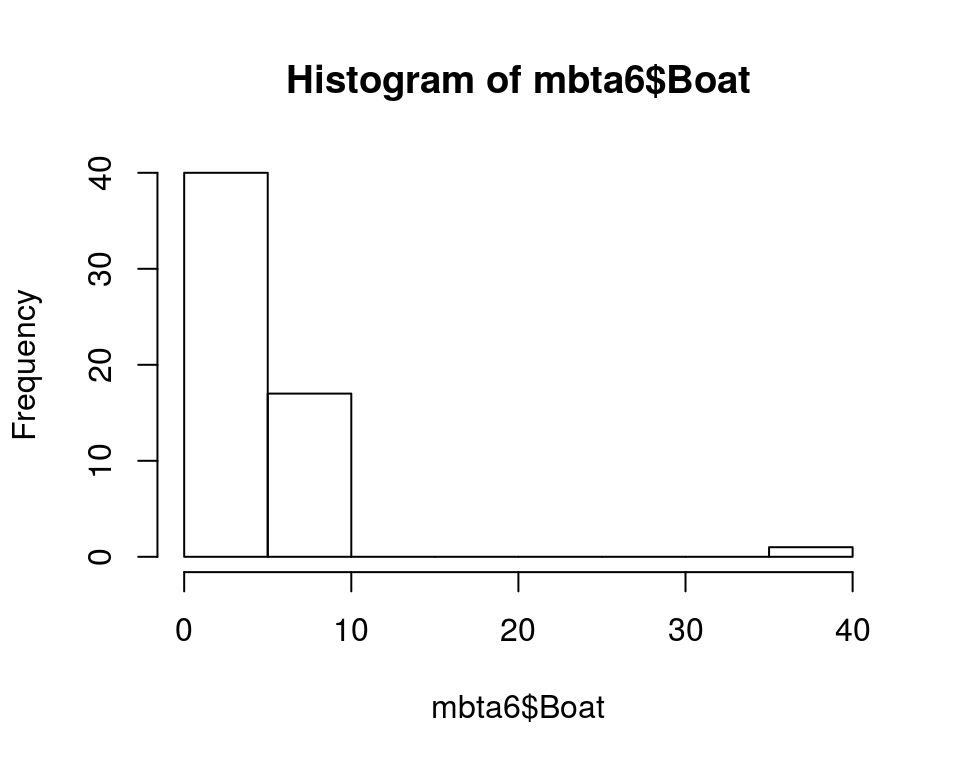

```r
# Generate a histogram of Boat column
hist(mbta6$Boat)
```

Replace this 40 by a 4 to correct the outlier.

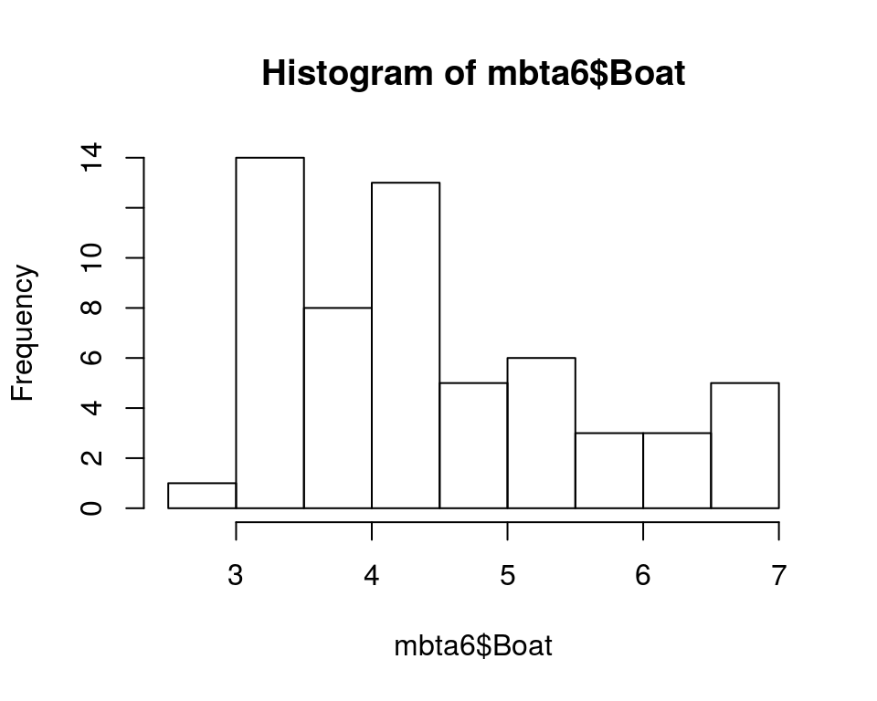

```r
# Find the row number of the incorrect value: i
i<-which(mbta6$Boat==40)

# Replace the incorrect value with 4
mbta6$Boat[i]<-4

# Generate a histogram of Boat column
hist(mbta6$Boat)
```

## **Exercise 3_Nutrition_Food**

Data_Sales: https://www.datacamp.com/courses/importing-cleaning-data-in-r-case-studies Data_file: food.csv

### **Importing**

A large dataset called food.csv is ready for your use in the working directory. Instead of the usual read.csv(), however, you’re going to use the faster **fread()** from the **data.table package**. The data will come in as a data table, but since you’re used to working with data frames, you can just convert it.

```r
library(data.table)
# Import food.csv: dt_food
dt_food<- fread("food.csv")

# Convert dt_food to a data frame
df_food<- data.frame(dt_food)
```

### **Examining**

```r
summary(df_food)
```

```
##        V1              code            url              creator
##  Min.   :   1.0   Min.   :100030   Length:1500        Length:1500
##  1st Qu.: 375.8   1st Qu.:124974   Class :character   Class :character
##  Median : 750.5   Median :149514   Mode  :character   Mode  :character
##  Mean   : 750.5   Mean   :149613
##  3rd Qu.:1125.2   3rd Qu.:174506
##  Max.   :1500.0   Max.   :199880
##
##    created_t         created_datetime   last_modified_t
##  Min.   :1.332e+09   Length:1500        Min.   :1.340e+09
##  1st Qu.:1.394e+09   Class :character   1st Qu.:1.424e+09
##  Median :1.425e+09   Mode  :character   Median :1.437e+09
##  Mean   :1.414e+09                      Mean   :1.430e+09
##  3rd Qu.:1.436e+09                      3rd Qu.:1.446e+09
##  Max.   :1.453e+09                      Max.   :1.453e+09
##
##  last_modified_datetime product_name       generic_name
##  Length:1500            Length:1500        Length:1500
##  Class :character       Class :character   Class :character
##  Mode  :character       Mode  :character   Mode  :character
##
##
##
##
##    quantity          packaging         packaging_tags
##  Length:1500        Length:1500        Length:1500
##  Class :character   Class :character   Class :character
##  Mode  :character   Mode  :character   Mode  :character
##
##
##
##
##     brands          brands_tags         categories
##  Length:1500        Length:1500        Length:1500
##  Class :character   Class :character   Class :character
##  Mode  :character   Mode  :character   Mode  :character
##
##
##
##
```

[output cut: 329 more lines]

```
##  Min.   :12.00                    Min.   :30     Mode:logical
##  1st Qu.:13.50                    1st Qu.:47     NA's:1500
##  Median :15.00                    Median :60
##  Mean   :15.67                    Mean   :57
##  3rd Qu.:17.50                    3rd Qu.:70
##  Max.   :20.00                    Max.   :81
##  NA's   :1497                     NA's   :1491
##  carbon_footprint_100g nutrition_score_fr_100g nutrition_score_uk_100g
##  Min.   : 12.00        Min.   :-12.000         Min.   :-12.000
##  1st Qu.: 97.42        1st Qu.:  1.000         1st Qu.:  0.000
##  Median :182.85        Median :  7.000         Median :  6.000
##  Mean   :131.18        Mean   :  7.941         Mean   :  7.631
##  3rd Qu.:190.78        3rd Qu.: 15.000         3rd Qu.: 16.000
##  Max.   :198.70        Max.   : 28.000         Max.   : 28.000
##  NA's   :1497          NA's   :825             NA's   :825
```

```r
library(dplyr)
glimpse(df_food)
```

```
## Observations: 1,500
## Variables: 160
## $ V1                                         <int> 1, 2, 3, 4, 5, 6, 7...
## $ code                                       <int> 100030, 100050, 100...
## $ url                                        <chr> "http://world-en.op...
## $ creator                                    <chr> "sebleouf", "foodor...
## $ created_t                                  <int> 1424747544, 1450316...
## $ created_datetime                           <chr> "2015-02-24T03:12:2...
## $ last_modified_t                            <int> 1438445887, 1450817...
## $ last_modified_datetime                     <chr> "2015-08-01T16:18:0...
## $ product_name                               <chr> "Confiture de frais...
## $ generic_name                               <chr> "", "", "Pâtes de f...
## $ quantity                                   <chr> "265 g", "375g", "1...
## $ packaging                                  <chr> "Bocal,Verre", "Pla...
## $ packaging_tags                             <chr> "bocal,verre", "pla...
```

[output cut: 147 more lines]

```r
# View column names of food
names(df_food)
```

```
##   [1] "V1"
##   [2] "code"
##   [3] "url"
##   [4] "creator"
##   [5] "created_t"
##   [6] "created_datetime"
##   [7] "last_modified_t"
##   [8] "last_modified_datetime"
##   [9] "product_name"
##  [10] "generic_name"
##  [11] "quantity"
##  [12] "packaging"
##  [13] "packaging_tags"
##  [14] "brands"
##  [15] "brands_tags"
```

[output cut: 145 more lines]

### **Removing Duplicates**

A vector has been created for you that lists out all of the duplicates; all you need to do is remove those columns from the dataset.

```r
# Define vector of duplicate cols
duplicates <- c(4, 6, 11, 13, 15, 17, 18, 20, 22,
                24, 25, 28, 32, 34, 36, 38, 40,
                44, 46, 48, 51, 54, 65, 158)

# Remove duplicates from food: food2
food2<-df_food[,-duplicates]
```

### **Removing Useless Info**

```r
# Define useless vector
useless <- c(1, 2, 3, 32:41)

# Remove useless columns from food2: food3
food3<-food2[,-useless]
```

### **Finding columns**

All of the columns with nutrition info contain the character string “100g” as part of their name, which makes it easy to identify them.

```r
#Create a vector called nutrition containing the column indices of the nutrition data. To do this, use a stringr function on the column names of food3 to determine which columns contain "100g" in their name.

library(stringr)
nutrition <- str_detect(names(food3), pattern = "100g")

#View a summary of the nutrition columns.
summary(food3[,nutrition])
```

```
##  energy_from_fat_100g    fat_100g      saturated_fat_100g
##  Min.   :   0.00      Min.   :  0.00   Min.   : 0.000
##  1st Qu.:  35.98      1st Qu.:  0.90   1st Qu.: 0.200
##  Median : 237.00      Median :  6.00   Median : 1.700
##  Mean   : 668.41      Mean   : 13.39   Mean   : 4.874
##  3rd Qu.: 974.00      3rd Qu.: 20.00   3rd Qu.: 6.500
##  Max.   :2900.00      Max.   :100.00   Max.   :57.000
##  NA's   :1486         NA's   :708      NA's   :797
##  butyric_acid_100g caproic_acid_100g caprylic_acid_100g capric_acid_100g
##  Mode:logical      Mode:logical      Mode:logical       Mode:logical
##  NA's:1500         NA's:1500         NA's:1500          NA's:1500
##
##
##
##
##
##  lauric_acid_100g myristic_acid_100g palmitic_acid_100g stearic_acid_100g
##  Mode:logical     Mode:logical       Mode:logical       Mode:logical
##  NA's:1500        NA's:1500          NA's:1500          NA's:1500
##
##
##
##
##
##  arachidic_acid_100g behenic_acid_100g lignoceric_acid_100g
##  Mode:logical        Mode:logical      Mode:logical
##  NA's:1500           NA's:1500         NA's:1500
##
##
##
##
##
##  cerotic_acid_100g montanic_acid_100g melissic_acid_100g
##  Mode:logical      Mode:logical       Mode:logical
##  NA's:1500         NA's:1500          NA's:1500
##
##
##
##
##
```

[output cut: 161 more lines]

```
##  Min.   :12.00                    Min.   :30     Mode:logical
##  1st Qu.:13.50                    1st Qu.:47     NA's:1500
##  Median :15.00                    Median :60
##  Mean   :15.67                    Mean   :57
##  3rd Qu.:17.50                    3rd Qu.:70
##  Max.   :20.00                    Max.   :81
##  NA's   :1497                     NA's   :1491
##  nutrition_score_fr_100g nutrition_score_uk_100g
##  Min.   :-12.000         Min.   :-12.000
##  1st Qu.:  1.000         1st Qu.:  0.000
##  Median :  7.000         Median :  6.000
##  Mean   :  7.941         Mean   :  7.631
##  3rd Qu.: 15.000         3rd Qu.: 16.000
##  Max.   : 28.000         Max.   : 28.000
##  NA's   :825             NA's   :825
```

### **Replacing missing values**

In this exercise, you’ll replace all NA values with zeroes in the sugars_100g column and make histograms to visualize the result. Then, you will exclude the observations which have no sugar to see how the distribution changes.

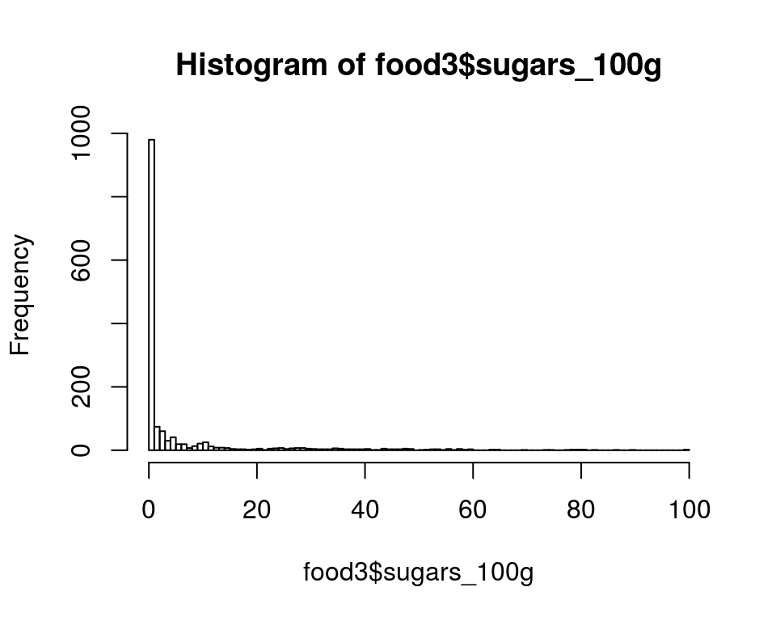

```r
# Find indices of sugar NA values: missing
missing <- is.na(food3$sugars_100g)

# Replace NA values with 0
food3$sugars_100g[missing] <- 0

# Create first histogram
hist(food3$sugars_100g, breaks = 100)
```

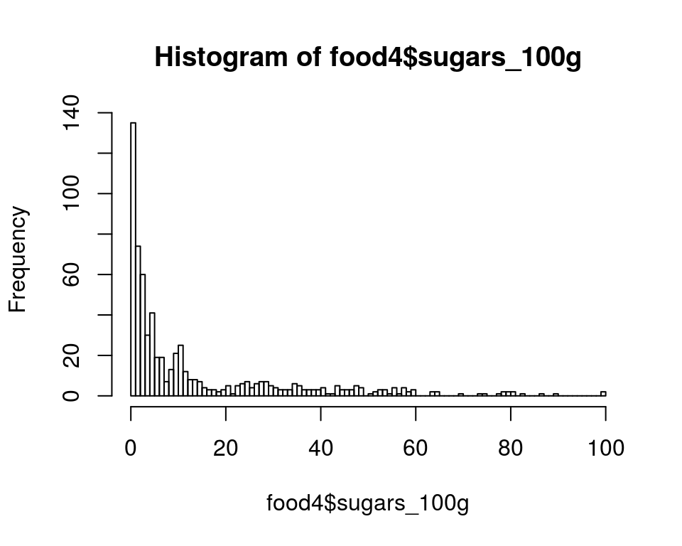

```r
# Create food4
food4 <- food3[food3$sugars_100g > 0, ]

# Create second histogram
hist(food4$sugars_100g, breaks = 100)
```

```r
#To get a general idea of how many of these foods are packaged in plastic, you can look through the packaging column for the string "plasti".

# Find entries containing "plasti": plastic
plastic <- str_detect(food3$packaging, "plasti")

# Print the sum of plastic
sum(plastic)
```

```
## [1] 232
```

## **Exercise 4_PublicSchools_Attendance**

Data_Sales: https://www.datacamp.com/courses/importing-cleaning-data-in-r-case-studies Data_file: attendance.xls

In this chapter, you’ll work with attendance data from public schools in the US, organized by school level and state, during the 2007-2008 academic year. The data contain information on average daily attendance (ADA) as a percentage of total enrollment, school day length, and school year length.

### **Importing**

```r
# Load the gdata package
library(gdata)
# Import the spreadsheet: att
att<- read.xls("attendance.xls")
```

### **Examining the data**

```r
str(att)
```

```
## 'data.frame':    59 obs. of  17 variables:
##  $ Table.43..Average.daily.attendance..ADA..as.a.percentage.of.total.enrollment..school.day.length..and.school.year.length.in.public.schools..by.school.level.and.state..2007.08: Factor w/ 58 levels "","1","Alabama .................",..: 1 1 2 51 3 4 5 6 7 8 ...
##  $ X                                                                                                                                                                            : Factor w/ 42 levels "","2","\\ 2003-04 and 2007-08. (This table was prepared June 2011.)",..: 42 41 2 22 28 8 6 14 23 2…
##  $ X.1                                                                                                                                                                          : Factor w/ 45 levels "","(0.22)","(0.23)",..: 1 1 1 2 22 21 41 27 14 6 ...
##  $ X.2                                                                                                                                                                          : Factor w/ 14 levels "","3","6.2","6.3",..: 1 14 2 7 11 6 5 10 3 11 ...
##  $ X.3                                                                                                                                                                          : Factor w/ 14 levels "","(0.02)","(0.03)",..: 1 1 1 2 7 5 9 6 7 5 ...
##  $ X.4                                                                                                                                                                          : Factor w/ 15 levels "","171","172",..: 1 15 14 10 10 10 11 9 11 2 ...
##  $ X.5                                                                                                                                                                          : Factor w/ 22 levels "","(0.0)","(0.1)",..: 1 1 1 3 10 21 19 4 6 12 ...
##  $ X.6                                                                                                                                                                          : Factor w/ 48 levels "","1,102","1,117",..: 1 48 47 26 45 15 13 36 5 28 ...
##  $ X.7                                                                                                                                                                          : Factor w/ 48 levels "","(10.1)","(10.3)",..: 1 1 1 36 11 35 22 6 13 48 ...
##  $ X.8                                                                                                                                                                          : Factor w/ 40 levels "","6","81.0",..: 40 39 2 22 20 9 5 13 27 25 ...
##  $ X.9                                                                                                                                                                          : Factor w/ 51 levels "","(0.24)","(0.25)",..: 1 1 1 4 32 25 48 35 20 13 ...
##  $ X.10                                                                                                                                                                         : Factor w/ 14 levels "","6.2","6.3",..: 1 14 10 7 11 5 4 9 3 11 ...
##  $ X.11                                                                                                                                                                         : Factor w/ 13 levels "","(0.02)","(0.03)",..: 1 1 1 2 8 5 10 8 5 7 ...
##  $ X.12                                                                                                                                                                         : Factor w/ 41 levels "","‡","8","85.8",..: 41 40 3 19 35 30 8 18 9 20 ...
##  $ X.13                                                                                                                                                                         : Factor w/ 47 levels "","(†)","(0.35)",..: 1 1 1 7 5 25 43 35 23 20 ...
##  $ X.14                                                                                                                                                                         : Factor w/ 17 levels "","‡","5.9","6.1",..: 1 17 16 9 14 5 7 11 4 13 ...
##  $ X.15                                                                                                                                                                         : Factor w/ 29 levels "","(†)","(0.03)",..: 1 1 1 4 15 13 21 8 18 9 ...
```

These are some messy data! The column names are mostly missing, there are irrelevant notes at the end of the data frame, and it looks like the numeric data were imported as factors. Let’s start the cleaning process!

### **Removing unnecessary rows**

When you’re importing a messy spreadsheet into R, it’s good practice to compare the original spreadsheet with what you’ve imported. It turns out that, by default, the read.xls() function skips empty rows such as the 11th and 17th.

After viewing your data frame, you realize you still need to get rid of the third row of att, as well as rows 56 through 59.

```r
# Create remove
remove<-c(3,56:59)

# Create att2
att2<- att[-(remove),]
```

### **Removing useless columns**

```r
# Create remove
remove<-c(3, 5, 7, 9, 11, 13, 15, 17)

# Create att3
att3<- att2[,-remove]
```

### **Splitting the data**

In many cases, a single data frame stores multiple “tables” of information. You can often diagnose this problem by looking at the column names and noticing duplicate rows.

In this data frame, columns 1, 6, and 7 represent attendance data for US elementary schools, columns 1, 8, and 9 represent data for secondary schools, and columns 1 through 5 represent data for all schools in the US.

Each of these should be stored as its own separate data frame, so you’ll split them up here.

```r
#Subset att3 to include only data for elementary schools (columns 1, 6, and 7). Name the resulting data frame att_elem.

att_elem<- att3[,c(1,6,7)]

#Subset att3 to include only data for secondary schools (columns 1, 8, and 9). Name the resulting data frame att_sec.

att_sec<- att3[,c(1,8,9)]

#Subset att3 to include data for all schools (columns 1 through 5). Name the resulting data frame att4.
att4<- att3[, c(1:5)]
```

### **Replacing the names**

Since you went through so much trouble finding out which row stored the variable names, you should store that row as the actual column names of the data frame. We’ve modified the names a bit in order to be more stylistically sound; they’re stored as cnames in the editor.

This will also allow you to remove the first two rows (currently storing variable names).

```r
# Define cnames vector (don't change)
cnames <- c("state", "avg_attend_pct", "avg_hr_per_day",
            "avg_day_per_yr", "avg_hr_per_yr")

# Assign column names of att4
colnames(att4) <- cnames

# Remove first two rows of att4: att5
att5<- att4[-c(1,2),]

# View the names of att5
names(att5)
```

```
## [1] "state"          "avg_attend_pct" "avg_hr_per_day" "avg_day_per_yr"
## [5] "avg_hr_per_yr"
```

### **Cleaning up extra characters**

One of the most irritating things about this dataset is that the state names are all stored as the same number of characters, with periods padding the ends of the shorter states. That may be helpful for reading the spreadsheet, but it makes your life harder, so you’ll deal with it in this exercise.

One pitfall to avoid: . is a special character in the language of regular expressions (a.k.a. regex). In order to specify that you actually want to remove periods and not their regex equivalent (which is “all characters”), use \.. This is called an “escape” sequence.

```r
library(stringr)

#Use the function str_replace_all() to replace all periods in the state column of att5 with "". Remember to use \\. to represent a period. Assign the result back to att5$state.

att5$state<- str_replace_all(att5$state,pattern="\\.", "")

#Remove white space around the state names, assigning the result back to att5$state once more. There's another stringr function called str_trim() for this purpose.
att5$state <- str_trim(att5$state)
head(att5, n=20)
```

```
##                   state avg_attend_pct avg_hr_per_day avg_day_per_yr
## 4         United States           93.1            6.6            180
## 5               Alabama           93.8            7.0            180
## 6                Alaska           89.9            6.5            180
## 7               Arizona           89.0            6.4            181
## 8              Arkansas           91.8            6.9            179
## 9            California           93.2            6.2            181
## 10             Colorado           93.9            7.0            171
## 11          Connecticut           87.9            6.5            181
## 12             Delaware           89.8            6.7            181
## 13 District of Columbia           91.2            6.9            181
## 14              Florida           92.7            6.4            184
## 15              Georgia           93.3            6.8            181
## 16               Hawaii           90.7            6.3            179
## 17                Idaho           92.4            6.6            173
```

[output cut: 27 more lines]

——————————FIN———————————————–